# bowling_adults

Desmond Ong, Mika Asaba

May 11, 2016

### Experiment 1 Results.

Children: All children correctly reported the number of pins knocked down in every trial. There were no significant effects of trial order, nor of characters. On the Strike and Gutter practice trials, 4 year-olds and 5 year-olds provided higher ratings to the Strike character than the Gutter character (4 year-olds: Strike vs. Gutter: M(SD) = 5.95 (0.22) vs. 1.3 (0.57) , t(19) = 35.42, p = 8.14e-19; 5 year-olds: Strike vs. Gutter: M(SD) = 5.95 (0.22) vs. 1.7 (0.57), t(19) = 29.76, p = 2.1e-17). When given a binary choice between the Strike and Gutter character, all children in both age groups reported that the Strike character was happier than the Gutter character (4 year-olds: 20 of 20 chose Strike, p < 0.001; 5 year-olds: 20 of 20 chose Strike, p < 0.001).

Next, we examined ratings for the test trials (Fig. 2). Recall that both trials have identical outcomes (3 pins knocked down) but they differ with respect to the balls’ initial trajectories (and thus agents’ prior expectations). Four year-olds’ provided the same ratings for the Low Expectation and High Expectation characters (Low Exp. vs. High Exp.: M(SD) = 4.7 (1.34) vs. 4.85 (1.14) , t(19) = -0.5472, p = 0.591), whereas five year-olds reported higher ratings for the Low Expectation character than for the High Expectation character (Low Exp. vs. High Exp.: M(SD) = 4.8 (0.951) vs. 4.3 (1.22) , t(19) = 2.127, p = 0.0467). When given a forced choice between the Low Expectation and High Expectation character, neither group showed a strong tendency to choose the Low Expectation character (binomial test, p = ns for both), but we note that more five-olds chose this character over the High Expectation character (13 of 20 five-year-olds vs. 9 of 20 four-year-olds).

Adults: Adults’ responses were consistent with the 5 year-olds’ ratings, providing higher emotion ratings to the Low Expectation character than the High Expectation character (Low Exp. vs. High Exp.: M(SD) = 4.39 (0.743) vs. 3.86 (0.798), t(58) = 4.597, p = 2.37e-05). On the final forced choice question, 23 (of 59) participants chose the Low Expectation character as feeling happier, 2 chose the High Expectation character, and the remaining 34 said that both feel equally happy.

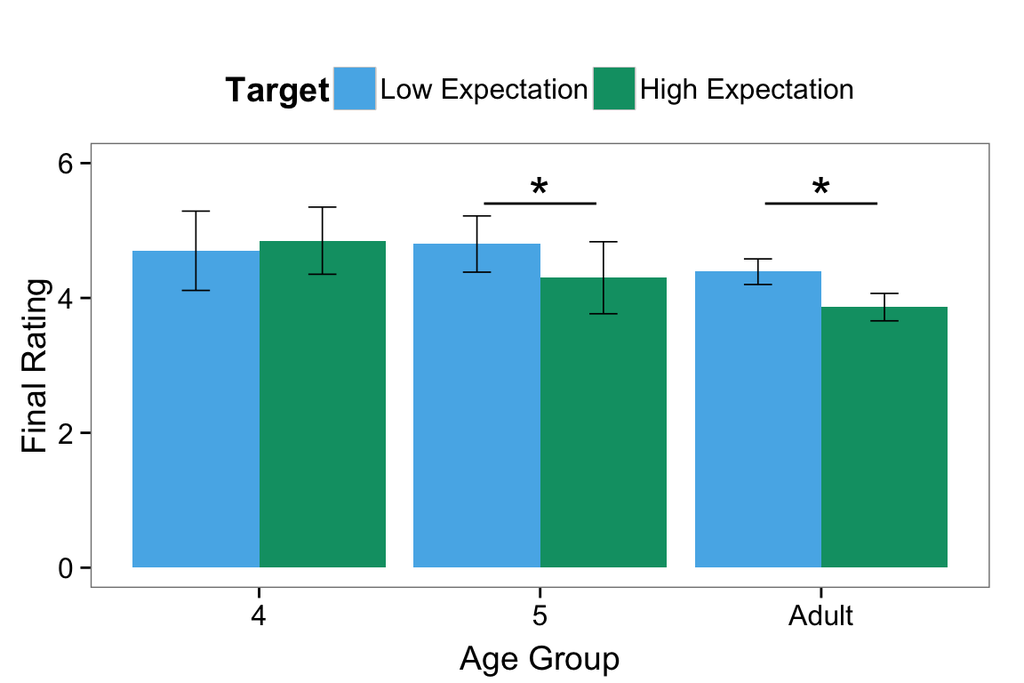

### Experiment 2 Results.

All children correctly answered the number of pins knocked down in each trial. We observed no effect of trial order or character. For the Strike and Gutter practice trials, both 4- and 5-year-olds successfully reported that the Gutter character was sad (4 year-olds: 17 of 18; 5 year-olds: 18 of 18, p <0.001 by binom. test for both) and the Strike character was happy (4 year-olds: 17 of 18; 5 year-olds: 17 of 18, p <0.001 by binom. test for both). All children in both age groups chose the Strike character as happier than the Gutter character (4-year-olds: 18 of 18; 5-year-olds: 18 of 18, p <0.001 by binom. test for both).

We found that 4-year- olds’ final ratings for the Low Expectation and High Expectation characters did not differ (Low Exp. vs. High Exp.: M(SD) = 5.17(1.91) vs. 5.44(1.21), t(17) = .79, p = ns), whereas 5-year-olds rated the Low Expectation character as being happier than the High Expectation character (Low Exp. vs. High Exp.: M(SD) = 5.86(1.66) vs. 4.81(2.11), t(17) = 2.60, p = .05). Lastly, given a binary forced choice, neither group was able to report that the Low Expectation character was happier than the High Expectation character (p = ns for both). However, 5-year-olds tended to choose the Low Expectation more often (12 of 18 5-year-olds vs. 8 of 18 4- year-olds).

Overall, adult participants responded as we predicted on all the questions. Participants reported that the Low Expectation character felt sad initially (57 of 58) and felt better after seeing the outcome (58 of 58); they thought the High Expectation character felt happy initially (56 of 58) and felt worse after the outcome (46 of 58). Adults’ ratings were significantly higher for the Low Expectation character (Low Exp. vs. High Exp.: M(SD) = 6.33 (.98) vs. 4.62 (0.89), t(57)=10.46, p <0.001). On the forced choice question, 42 chose the Low Expectation character as feeling happier, and the remaining 16 said that both characters feel equally happy.

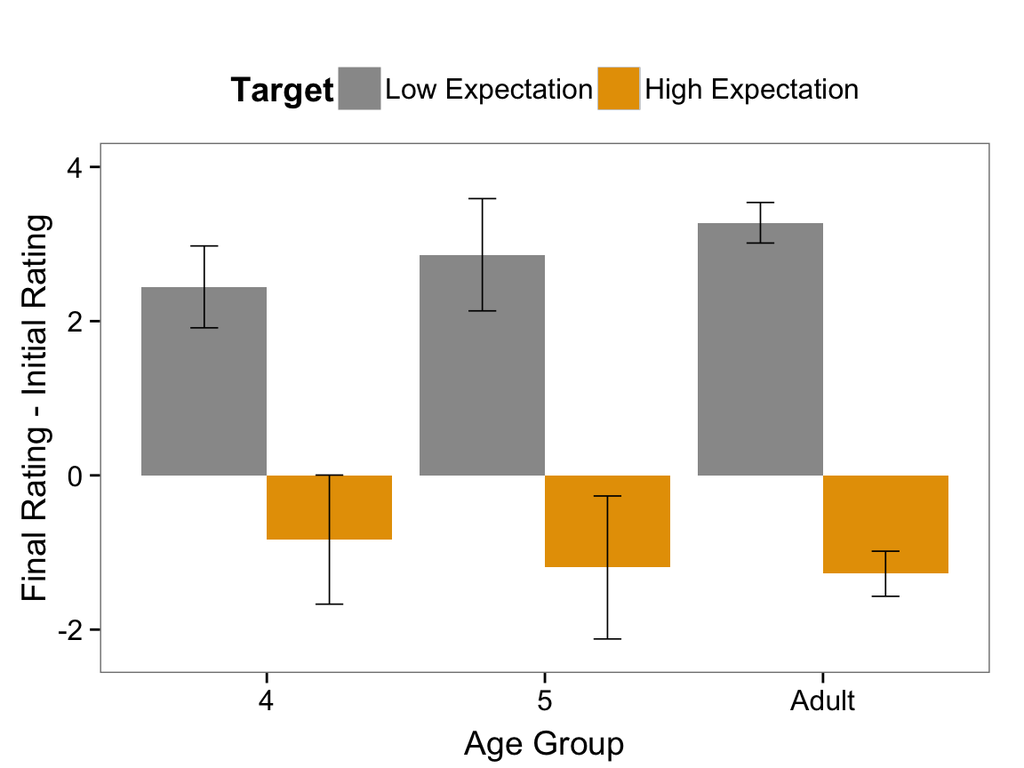